# Notebook

**# 📊 Scalable BI Pipeline: SQL & Tableau Executive Intelligence System**

**Dataset Source**: [Kaggle - Brazilian E-Commerce](https://www.kaggle.com/datasets/olistbr/brazilian-ecommerce)

**Tools Used**:

- Python (pandas, sqlite3)
- SQL
- Matplotlib & Seaborn

```python
import sqlite3
import pandas as pd
from IPython.display import display
import matplotlib.pyplot as plt
import seaborn as sns
```

## 📥 Step 1: Load CSV Data

We begin by reading all the CSV files provided in the dataset and converting them to pandas DataFrames.

```python
df_customers = pd.read_csv('/content/olist_customers_dataset.csv')
df_geolocation = pd.read_csv('/content/olist_geolocation_dataset.csv')
df_order_items = pd.read_csv('/content/olist_order_items_dataset.csv')
df_order_payments = pd.read_csv('/content/olist_order_payments_dataset.csv')
df_order_reviews = pd.read_csv('/content/olist_order_reviews_dataset.csv')
df_orders = pd.read_csv('/content/olist_orders_dataset.csv')
df_products = pd.read_csv('/content/olist_products_dataset.csv')
df_sellers = pd.read_csv('/content/olist_sellers_dataset.csv')
df_product_category_name_translation = pd.read_csv('/content/product_category_name_translation.csv')
```

## 🗄️ Step 2: Load Data into SQLite Database

Using `sqlite3`, we store all the data into a local SQLite database (`oblist.db`) for running SQL queries.

```python
conn = sqlite3.connect('oblist.db')
c = conn.cursor()
```

```python
df_customers.to_sql('olist_customers_dataset', conn, if_exists='replace', index=False)
```

```
99441
```

```python
df_geolocation.to_sql('olist_geolocation_dataset', conn, if_exists='replace', index=False)
```

```
1000163
```

```python
df_order_items.to_sql('olist_order_items_dataset', conn, if_exists='replace', index=False)
```

```
112650
```

```python
df_order_payments.to_sql('olist_order_payments_dataset', conn, if_exists='replace', index=False)
```

```
103886
```

```python
df_order_reviews.to_sql('olist_order_reviews_dataset', conn, if_exists='replace', index=False)
```

```
99224
```

```python
df_orders.to_sql('olist_orders_dataset', conn, if_exists='replace', index=False)
```

```
99441
```

```python
df_products.to_sql('olist_products_dataset', conn, if_exists='replace', index=False)
```

```
32951
```

```python
df_sellers.to_sql('olist_sellers_dataset', conn, if_exists='replace', index=False)
```

```
3095
```

```python
df_product_category_name_translation.to_sql('product_category_name_translation', conn, if_exists='replace', index=False)
```

```
71
```

```python
df_orders.head()
```

|  | order_id | customer_id | order_status | order_purchase_timestamp | order_approved_at | order_delivered_carrier_date | order_delivered_customer_date | order_estimated_delivery_date |
| --- | --- | --- | --- | --- | --- | --- | --- | --- |
| 0 | e481f51cbdc54678b7cc49136f2d6af7 | 9ef432eb6251297304e76186b10a928d | delivered | 2017-10-02 10:56:33 | 2017-10-02 11:07:15 | 2017-10-04 19:55:00 | 2017-10-10 21:25:13 | 2017-10-18 00:00:00 |
| 1 | 53cdb2fc8bc7dce0b6741e2150273451 | b0830fb4747a6c6d20dea0b8c802d7ef | delivered | 2018-07-24 20:41:37 | 2018-07-26 03:24:27 | 2018-07-26 14:31:00 | 2018-08-07 15:27:45 | 2018-08-13 00:00:00 |
| 2 | 47770eb9100c2d0c44946d9cf07ec65d | 41ce2a54c0b03bf3443c3d931a367089 | delivered | 2018-08-08 08:38:49 | 2018-08-08 08:55:23 | 2018-08-08 13:50:00 | 2018-08-17 18:06:29 | 2018-09-04 00:00:00 |
| 3 | 949d5b44dbf5de918fe9c16f97b45f8a | f88197465ea7920adcdbec7375364d82 | delivered | 2017-11-18 19:28:06 | 2017-11-18 19:45:59 | 2017-11-22 13:39:59 | 2017-12-02 00:28:42 | 2017-12-15 00:00:00 |
| 4 | ad21c59c0840e6cb83a9ceb5573f8159 | 8ab97904e6daea8866dbdbc4fb7aad2c | delivered | 2018-02-13 21:18:39 | 2018-02-13 22:20:29 | 2018-02-14 19:46:34 | 2018-02-16 18:17:02 | 2018-02-26 00:00:00 |

## 🔍 Step 3: Understand the Schema

We print out the column names of each dataset to get an overview of the available fields for analysis.

```python
print('The columns of olist_customers are :-  ',df_customers.columns)
print('\n')
print('The columns of olist_sellers are :-  ',df_sellers.columns)
print('\n')
print('The columns of olist_order_reviews are :-  ',df_geolocation.columns)
print('\n')
print('The columns of olist_order_items are :-  ',df_order_items.columns)
print('\n')
print('The columns of olist_products are :-  ',df_products.columns)
print('\n')
print('The columns of olist_geolocation are :-  ',df_order_reviews.columns)
print('\n')
print('The columns of product_category_name_translation are :-  ',df_product_category_name_translation.columns)
print('\n')
print('The columns of olist_orders_dataset are :-  ',df_orders.columns)
print('\n')
print('The columns of olist_order_payments are :-  ',df_order_payments.columns)
```

```
The columns of olist_customers are :-   Index(['customer_id', 'customer_unique_id', 'customer_zip_code_prefix',
       'customer_city', 'customer_state'],
      dtype='object')


The columns of olist_sellers are :-   Index(['seller_id', 'seller_zip_code_prefix', 'seller_city', 'seller_state'], dtype='object')


The columns of olist_order_reviews are :-   Index(['geolocation_zip_code_prefix', 'geolocation_lat', 'geolocation_lng',
       'geolocation_city', 'geolocation_state'],
      dtype='object')


The columns of olist_order_items are :-   Index(['order_id', 'order_item_id', 'product_id', 'seller_id',
       'shipping_limit_date', 'price', 'freight_value'],
      dtype='object')


The columns of olist_products are :-   Index(['product_id', 'product_category_name', 'product_name_lenght',
       'product_description_lenght', 'product_photos_qty', 'product_weight_g',
       'product_length_cm', 'product_height_cm', 'product_width_cm'],
      dtype='object')


The columns of olist_geolocation are :-   Index(['review_id', 'order_id', 'review_score', 'review_comment_title',
       'review_comment_message', 'review_creation_date',
       'review_answer_timestamp'],
      dtype='object')


The columns of product_category_name_translation are :-   Index(['product_category_name', 'product_category_name_english'], dtype='object')


The columns of olist_orders_dataset are :-   Index(['order_id', 'customer_id', 'order_status', 'order_purchase_timestamp',
       'order_approved_at', 'order_delivered_carrier_date',
       'order_delivered_customer_date', 'order_estimated_delivery_date'],
      dtype='object')


The columns of olist_order_payments are :-   Index(['order_id', 'payment_sequential', 'payment_type',
       'payment_installments', 'payment_value'],
      dtype='object')
```

# **Query 1: Count and % of Orders Purchased in Jan 2018 with 5-Star Review**

```python
c.execute('''
WITH cte AS (
    SELECT COUNT(DISTINCT order_id) AS total_orders
    FROM olist_orders_dataset
    WHERE order_purchase_timestamp BETWEEN '2018-01-01' AND '2018-01-31'
),
cte2 AS (
    SELECT COUNT(DISTINCT ood.order_id) AS count_orders
    FROM olist_orders_dataset AS ood
    JOIN olist_order_reviews_dataset AS ord ON ood.order_id = ord.order_id
    WHERE ood.order_purchase_timestamp BETWEEN '2018-01-01' AND '2018-01-31'
      AND ord.review_score = 5
)
SELECT
    count_orders,
    total_orders,
    ROUND(100.0 * count_orders / total_orders, 2) AS percentage
FROM cte, cte2;
''')

df = pd.DataFrame(c.fetchall(), columns=['orders with 5 star reviews','total orders','percentage'])
display(df)
```

|  | orders with 5 star reviews | total orders | percentage |
| --- | --- | --- | --- |
| 0 | 3924 | 7013 | 55.95 |

# **Query 2: Customer purchase trend Year-on-Year**

```python
c.execute('''SELECT strftime('%Y', order_purchase_timestamp) as year,strftime('%m', order_purchase_timestamp) as month,count(distinct customer_id) as cnt
FROM olist_orders_dataset
WHERE order_status ='delivered' and order_delivered_customer_date is not null
GROUP BY year,month
ORDER BY year;''')
df = pd.DataFrame(c.fetchall(), columns=['year', 'month', 'cnt'])
df_pivot = df.pivot(index='month', columns='year', values='cnt').fillna(0).astype(int)
df_pivot = df_pivot.sort_index()
display(df_pivot)
```

| year month | 2016 | 2017 | 2018 |
| --- | --- | --- | --- |
| 01 | 0 | 750 | 7069 |
| 02 | 0 | 1653 | 6555 |
| 03 | 0 | 2546 | 7003 |
| 04 | 0 | 2303 | 6798 |
| 05 | 0 | 3545 | 6749 |
| 06 | 0 | 3135 | 6096 |
| 07 | 0 | 3872 | 6156 |
| 08 | 0 | 4193 | 6351 |
| 09 | 1 | 4150 | 0 |
| 10 | 265 | 4478 | 0 |
| 11 | 0 | 7288 | 0 |
| 12 | 1 | 5513 | 0 |

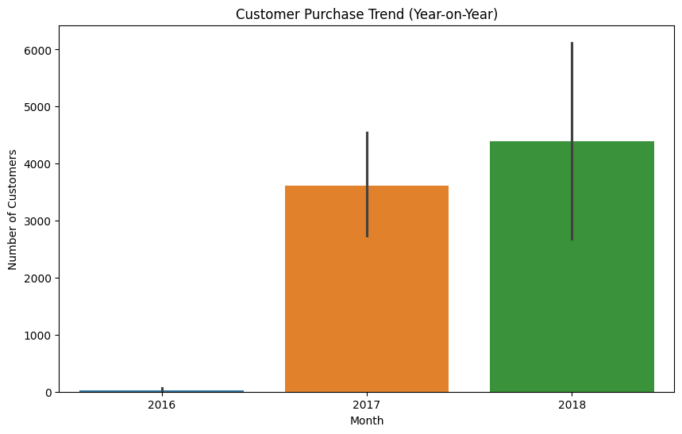

```python
plt.figure(figsize=(10, 6))
sns.barplot(data=df_pivot)
plt.xlabel('Month')
plt.ylabel('Number of Customers')
plt.title('Customer Purchase Trend (Year-on-Year)')
```

# **Query 3: Average Order Value per Customer**

```python
c.execute('''SELECT customer_id,
ROUND(SUM(olist_order_payments_dataset.payment_value), 2) AS total_spent,
COUNT(DISTINCT olist_order_payments_dataset.order_id) AS num_orders,
ROUND(SUM(olist_order_payments_dataset.payment_value) / COUNT(DISTINCT olist_order_payments_dataset.order_id), 2) AS avg_order_value
FROM olist_order_payments_dataset
JOIN olist_orders_dataset ON olist_order_payments_dataset.order_id = olist_orders_dataset.order_id
GROUP BY customer_id
ORDER BY avg_order_value DESC
LIMIT 10 ;''')
df = pd.DataFrame(c.fetchall(), columns=['customer_id','total_spent','num_orders', 'avg_order_value'])
display(df)
```

|  | customer_id | total_spent | num_orders | avg_order_value |
| --- | --- | --- | --- | --- |
| 0 | 1617b1357756262bfa56ab541c47bc16 | 13664.08 | 1 | 13664.08 |
| 1 | ec5b2ba62e574342386871631fafd3fc | 7274.88 | 1 | 7274.88 |
| 2 | c6e2731c5b391845f6800c97401a43a9 | 6929.31 | 1 | 6929.31 |
| 3 | f48d464a0baaea338cb25f816991ab1f | 6922.21 | 1 | 6922.21 |
| 4 | 3fd6777bbce08a352fddd04e4a7cc8f6 | 6726.66 | 1 | 6726.66 |
| 5 | 05455dfa7cd02f13d132aa7a6a9729c6 | 6081.54 | 1 | 6081.54 |
| 6 | df55c14d1476a9a3467f131269c2477f | 4950.34 | 1 | 4950.34 |
| 7 | e0a2412720e9ea4f26c1ac985f6a7358 | 4809.44 | 1 | 4809.44 |
| 8 | 24bbf5fd2f2e1b359ee7de94defc4a15 | 4764.34 | 1 | 4764.34 |
| 9 | 3d979689f636322c62418b6346b1c6d2 | 4681.78 | 1 | 4681.78 |

# **Query 4: Top 5 Cities with Highest Revenue (2016–2018)**

```python
c.execute('''SELECT
cu.customer_city,
ROUND(SUM(i.price), 2) AS total_revenue
FROM olist_orders_dataset o
JOIN olist_order_items_dataset i ON o.order_id = i.order_id
JOIN olist_customers_dataset cu ON o.customer_id = cu.customer_id
WHERE strftime('%Y', o.order_purchase_timestamp) BETWEEN '2016' AND '2018'
GROUP BY cu.customer_city
ORDER BY total_revenue DESC
LIMIT 5;''')

df = pd.DataFrame(c.fetchall(), columns=['City', 'Total Revenue'])
display(df)
```

|  | City | Total Revenue |
| --- | --- | --- |
| 0 | sao paulo | 1914924.54 |
| 1 | rio de janeiro | 992538.86 |
| 2 | belo horizonte | 355611.13 |
| 3 | brasilia | 301920.25 |
| 4 | curitiba | 211738.06 |

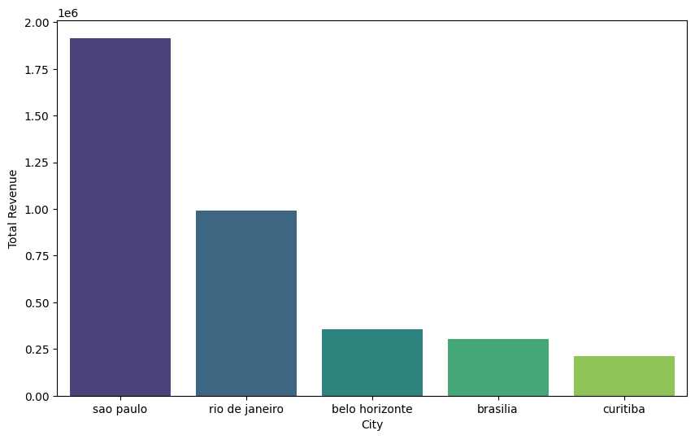

```python
plt.figure(figsize=(10, 6))
sns.barplot(x='City', y='Total Revenue', data=df,palette = 'viridis')
plt.xlabel('City')
plt.ylabel('Total Revenue')
```

# **Query 5: State-wise Revenue Table (2016–2018)**

```python
c.execute('''SELECT
  cu.customer_state,
  ROUND(SUM(i.price), 2) AS total_revenue
FROM olist_orders_dataset o
JOIN olist_order_items_dataset i ON o.order_id = i.order_id
JOIN olist_customers_dataset cu ON o.customer_id = cu.customer_id
WHERE strftime('%Y', o.order_purchase_timestamp) BETWEEN '2016' AND '2018'
GROUP BY cu.customer_state
ORDER BY total_revenue DESC;''')

df = pd.DataFrame(c.fetchall(), columns=['State', 'Total Revenue'])
display(df)
```

|  | State | Total Revenue |
| --- | --- | --- |
| 0 | SP | 5202955.05 |
| 1 | RJ | 1824092.67 |
| 2 | MG | 1585308.03 |
| 3 | RS | 750304.02 |
| 4 | PR | 683083.76 |
| 5 | SC | 520553.34 |
| 6 | BA | 511349.99 |
| 7 | DF | 302603.94 |
| 8 | GO | 294591.95 |
| 9 | ES | 275037.31 |
| 10 | PE | 262788.03 |
| 11 | CE | 227254.71 |
| 12 | PA | 178947.81 |
| 13 | MT | 156453.53 |
| 14 | MA | 119648.22 |
| 15 | MS | 116812.64 |
| 16 | PB | 115268.08 |
| 17 | PI | 86914.08 |
| 18 | RN | 83034.98 |
| 19 | AL | 80314.81 |
| 20 | SE | 58920.85 |
| 21 | TO | 49621.74 |
| 22 | RO | 46140.64 |
| 23 | AM | 22356.84 |
| 24 | AC | 15982.95 |
| 25 | AP | 13474.30 |
| 26 | RR | 7829.43 |

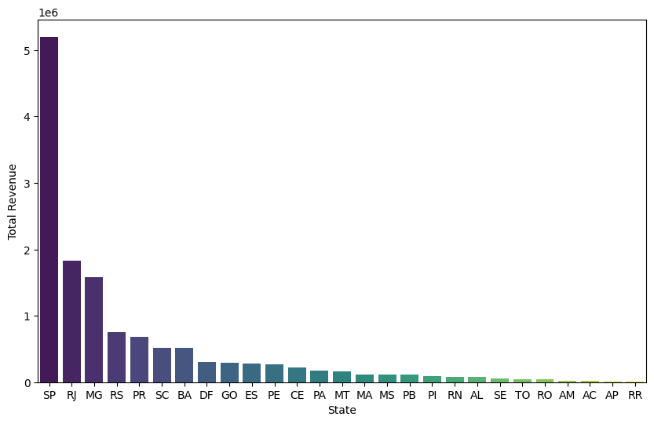

```python
plt.figure(figsize=(10, 6))
sns.barplot(x='State', y='Total Revenue', data=df,palette = 'viridis')
plt.xlabel('State')
plt.ylabel('Total Revenue')
```

# **Query 6: Top Successful Sellers (by units sold, revenue, customers, and 5-star reviews)**

```python
c.execute('''SELECT
  i.seller_id,
  COUNT(i.order_id) AS total_items_sold,
  ROUND(SUM(i.price), 2) AS total_revenue,
  COUNT(DISTINCT o.customer_id) AS unique_customers,
  SUM(CASE WHEN r.review_score = 5 THEN 1 ELSE 0 END) AS five_star_reviews
FROM olist_order_items_dataset i
JOIN olist_orders_dataset o ON i.order_id = o.order_id
JOIN olist_order_reviews_dataset r ON o.order_id = r.order_id
GROUP BY i.seller_id
ORDER BY total_items_sold DESC
LIMIT 5;''')

df = pd.DataFrame(c.fetchall(), columns=['Seller ID', 'Total Items Sold', 'Total Revenue', 'Unique Customers', '5-Star Reviews'])
display(df)
```

|  | Seller ID | Total Items Sold | Total Revenue | Unique Customers | 5-Star Reviews |
| --- | --- | --- | --- | --- | --- |
| 0 | 6560211a19b47992c3666cc44a7e94c0 | 2020 | 122484.82 | 1838 | 1024 |
| 1 | 4a3ca9315b744ce9f8e9374361493884 | 1984 | 200561.42 | 1785 | 947 |
| 2 | 1f50f920176fa81dab994f9023523100 | 1932 | 107002.21 | 1399 | 1096 |
| 3 | cc419e0650a3c5ba77189a1882b7556a | 1811 | 106059.06 | 1698 | 1053 |
| 4 | da8622b14eb17ae2831f4ac5b9dab84a | 1568 | 161993.97 | 1308 | 893 |

# **Query 7: Category-wise Order Volume and Revenue**

```python
c.execute('''SELECT
p.product_category_name,
COUNT(i.order_id) AS order_count,
ROUND(SUM(i.price), 2) AS total_revenue
FROM olist_order_items_dataset i
JOIN olist_products_dataset p ON i.product_id = p.product_id
GROUP BY p.product_category_name
ORDER BY total_revenue DESC
LIMIT 10;''')

df = pd.DataFrame(c.fetchall(), columns=['Category', 'Order Count', 'Total Revenue'])
display(df)
```

|  | Category | Order Count | Total Revenue |
| --- | --- | --- | --- |
| 0 | beleza_saude | 9670 | 1258681.34 |
| 1 | relogios_presentes | 5991 | 1205005.68 |
| 2 | cama_mesa_banho | 11115 | 1036988.68 |
| 3 | esporte_lazer | 8641 | 988048.97 |
| 4 | informatica_acessorios | 7827 | 911954.32 |
| 5 | moveis_decoracao | 8334 | 729762.49 |
| 6 | cool_stuff | 3796 | 635290.85 |
| 7 | utilidades_domesticas | 6964 | 632248.66 |
| 8 | automotivo | 4235 | 592720.11 |
| 9 | ferramentas_jardim | 4347 | 485256.46 |

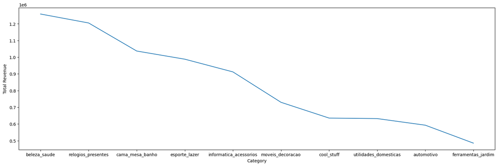

```python
plt.figure(figsize=(20, 6))
sns.lineplot(x='Category', y='Total Revenue', data=df)
plt.xlabel('Category')
plt.ylabel('Total Revenue')
```

# **Query 8: % of Orders Delivered Late vs On-Time**

```python
c.execute('''SELECT
  CASE
    WHEN julianday(order_delivered_customer_date) > julianday(order_estimated_delivery_date) THEN 'Late'
    ELSE 'On-Time'
  END AS delivery_status,
  COUNT(*) AS order_count,
  ROUND(100.0 * COUNT(*) / (SELECT COUNT(*) FROM olist_orders_dataset WHERE order_delivered_customer_date IS NOT NULL), 2) AS percentage
FROM olist_orders_dataset
WHERE order_delivered_customer_date IS NOT NULL
GROUP BY delivery_status;
''')
df = pd.DataFrame(c.fetchall(), columns=['Delivery Status', 'Order Count', 'Percentage'])
display(df)
```

|  | Delivery Status | Order Count | Percentage |
| --- | --- | --- | --- |
| 0 | Late | 7827 | 8.11 |
| 1 | On-Time | 88649 | 91.89 |

# **Query 9: Distribution of Review Scores**

```python
c.execute('''SELECT
  review_score,
  COUNT(*) AS total_reviews,
  ROUND(100.0 * COUNT(*) / (SELECT COUNT(*) FROM olist_order_reviews_dataset), 2) AS percentage
FROM olist_order_reviews_dataset
GROUP BY review_score
ORDER BY review_score DESC;
''')
df = pd.DataFrame(c.fetchall(), columns=['Review Score', 'Total Reviews', 'Percentage'])
display(df)
```

|  | Review Score | Total Reviews | Percentage |
| --- | --- | --- | --- |
| 0 | 5 | 57328 | 57.78 |
| 1 | 4 | 19142 | 19.29 |
| 2 | 3 | 8179 | 8.24 |
| 3 | 2 | 3151 | 3.18 |
| 4 | 1 | 11424 | 11.51 |